# Validation set vs training set LDA training - Approach two CIFAR100

```r
library(ggplot2)
library(dplyr)
library(tidyr)
library("ggpubr")
```

This experiment focuses on the question, whether training LDA on the same set of data as the neural networks were trained on has any adverse effects to the performance of the ensemble as opposed to training on a different set, not presented to the networks during the training. Experiment was performed with two slightly different approaches.

Approach one is described in the file visualization_base_experiment.

# CIFAR100

```r
net_results <- read.csv("../data/data_train_val_half_c100/net_accuracies.csv")
ens_results <- read.csv("../data/data_train_val_half_c100/ensemble_accuracies.csv")
```

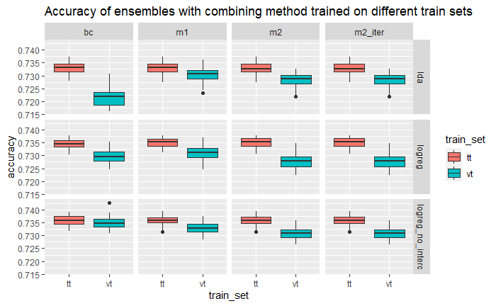

```r
box_acc <- ggplot() + geom_boxplot(data=ens_results, mapping = aes(x=train_set, y=accuracy, fill=train_set)) +
  facet_grid(rows=vars(combining_method), cols=vars(coupling_method)) +
  ggtitle("Accuracy of ensembles with combining method trained on different train sets")
box_acc
```

Training on the same training data as the neural networks were trained on seems to provide better accuracy compared to training on separate validation set. In case of lda is this difference bigger for bc coupling method, than for m1 and m2.

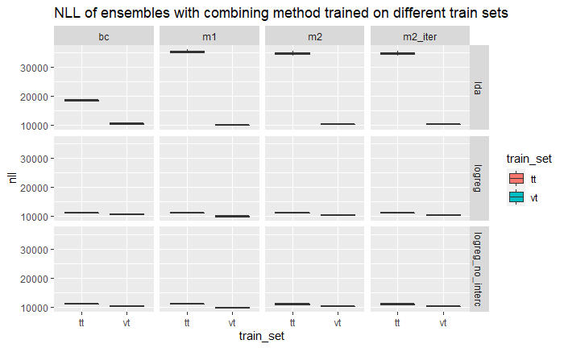

```r
box_nll <- ggplot() + geom_boxplot(data=ens_results, mapping = aes(x=train_set, y=nll, fill=train_set)) +
  facet_grid(rows=vars(combining_method), cols=vars(coupling_method)) +
  ggtitle("NLL of ensembles with combining method trained on different train sets")
box_nll
```

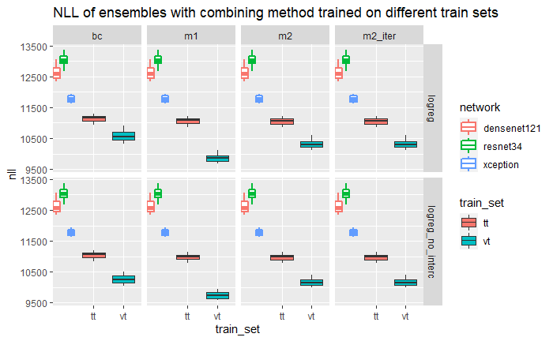

```r
box_nll <- ens_results %>% filter(combining_method!="lda") %>% ggplot() + geom_boxplot(mapping = aes(x=train_set, y=nll, fill=train_set)) +
  geom_boxplot(data=net_results, mapping=aes(y=nll, color=network), size=1) +
  facet_grid(rows=vars(combining_method), cols=vars(coupling_method)) +
  ggtitle("NLL of ensembles with combining method trained on different train sets")
box_nll
```

For some reason NLL has opposite trend to accuracy - train set with better accuracy has worse (larger) NLL. This needs some further attention.

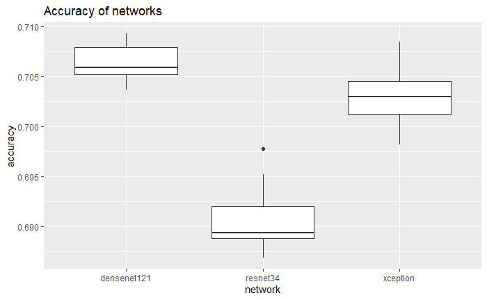

```r
box_net_acc <- ggplot() + geom_boxplot(data=net_results, mapping=aes(x=network, y=accuracy)) +
  ggtitle("Accuracy of networks")
box_net_acc
```

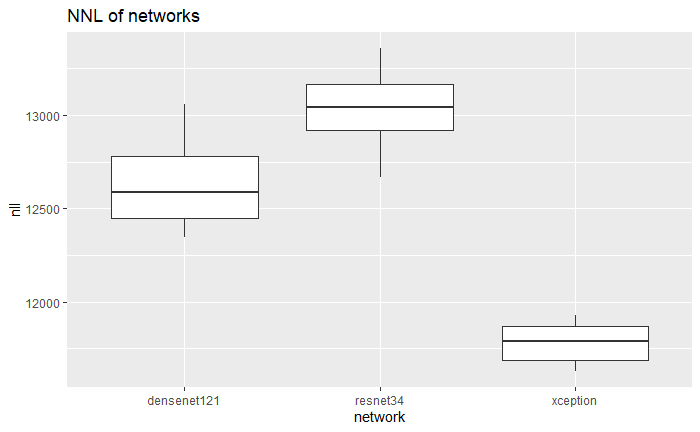

```r
box_net_nll <- ggplot() + geom_boxplot(data=net_results, mapping=aes(x=network, y=nll)) +
  ggtitle("NNL of networks")
box_net_nll
```

```r
ens_results_wide <- pivot_wider(ens_results, names_from = c(train_set, coupling_method), values_from = c(accuracy, nll))
```

Testing statistical significance of difference for training on validation and train data. We have 50 samples from each distribution, so we will suppose the distributions are normal.

### LDA

```r
ens_results_wide_lda <- ens_results_wide %>% filter(combining_method=="lda")
t.test(ens_results_wide_lda$accuracy_vt_m1, ens_results_wide_lda$accuracy_tt_m1)
```

```
    Welch Two Sample t-test

data:  ens_results_wide_lda$accuracy_vt_m1 and ens_results_wide_lda$accuracy_tt_m1
t = -4.9378, df = 97.431, p-value = 3.27e-06
alternative hypothesis: true difference in means is not equal to 0
95 percent confidence interval:
 -0.003524426 -0.001503574
sample estimates:
mean of x mean of y
 0.730504  0.733018
```

```r
t.test(ens_results_wide_lda$accuracy_vt_m1, ens_results_wide_lda$accuracy_tt_m1, alternative="less")
```

```
    Welch Two Sample t-test

data:  ens_results_wide_lda$accuracy_vt_m1 and ens_results_wide_lda$accuracy_tt_m1
t = -4.9378, df = 97.431, p-value = 1.635e-06
alternative hypothesis: true difference in means is less than 0
95 percent confidence interval:
         -Inf -0.001668516
sample estimates:
mean of x mean of y
 0.730504  0.733018
```

```r
t.test(ens_results_wide_lda$accuracy_vt_m2, ens_results_wide_lda$accuracy_tt_m2)
```

```
    Welch Two Sample t-test

data:  ens_results_wide_lda$accuracy_vt_m2 and ens_results_wide_lda$accuracy_tt_m2
t = -9.2709, df = 97.714, p-value = 4.74e-15
alternative hypothesis: true difference in means is not equal to 0
95 percent confidence interval:
 -0.005710941 -0.003697059
sample estimates:
mean of x mean of y
 0.728242  0.732946
```

```r
t.test(ens_results_wide_lda$accuracy_vt_m2, ens_results_wide_lda$accuracy_tt_m2, alternative="less")
```

```
    Welch Two Sample t-test

data:  ens_results_wide_lda$accuracy_vt_m2 and ens_results_wide_lda$accuracy_tt_m2
t = -9.2709, df = 97.714, p-value = 2.37e-15
alternative hypothesis: true difference in means is less than 0
95 percent confidence interval:
         -Inf -0.003861425
sample estimates:
mean of x mean of y
 0.728242  0.732946
```

```r
t.test(ens_results_wide_lda$accuracy_vt_m2_iter, ens_results_wide_lda$accuracy_tt_m2_iter)
```

```
    Welch Two Sample t-test

data:  ens_results_wide_lda$accuracy_vt_m2_iter and ens_results_wide_lda$accuracy_tt_m2_iter
t = -9.2709, df = 97.714, p-value = 4.74e-15
alternative hypothesis: true difference in means is not equal to 0
95 percent confidence interval:
 -0.005710941 -0.003697059
sample estimates:
mean of x mean of y
 0.728242  0.732946
```

```r
t.test(ens_results_wide_lda$accuracy_vt_m2_iter, ens_results_wide_lda$accuracy_tt_m2_iter, alternative="less")
```

```
    Welch Two Sample t-test

data:  ens_results_wide_lda$accuracy_vt_m2_iter and ens_results_wide_lda$accuracy_tt_m2_iter
t = -9.2709, df = 97.714, p-value = 2.37e-15
alternative hypothesis: true difference in means is less than 0
95 percent confidence interval:
         -Inf -0.003861425
sample estimates:
mean of x mean of y
 0.728242  0.732946
```

```r
t.test(ens_results_wide_lda$accuracy_vt_bc, ens_results_wide_lda$accuracy_tt_bc)
```

```
    Welch Two Sample t-test

data:  ens_results_wide_lda$accuracy_vt_bc and ens_results_wide_lda$accuracy_tt_bc
t = -20.565, df = 89.561, p-value < 2.2e-16
alternative hypothesis: true difference in means is not equal to 0
95 percent confidence interval:
 -0.01247944 -0.01028056
sample estimates:
mean of x mean of y
 0.721532  0.732912
```

```r
t.test(ens_results_wide_lda$accuracy_vt_bc, ens_results_wide_lda$accuracy_tt_bc, alternative="less")
```

```
    Welch Two Sample t-test

data:  ens_results_wide_lda$accuracy_vt_bc and ens_results_wide_lda$accuracy_tt_bc
t = -20.565, df = 89.561, p-value < 2.2e-16
alternative hypothesis: true difference in means is less than 0
95 percent confidence interval:
        -Inf -0.01046027
sample estimates:
mean of x mean of y
 0.721532  0.732912
```

### LogReg

```r
ens_results_wide_logreg <- ens_results_wide %>% filter(combining_method=="logreg")
t.test(ens_results_wide_logreg$accuracy_vt_m1, ens_results_wide_logreg$accuracy_tt_m1)
```

```
    Welch Two Sample t-test

data:  ens_results_wide_logreg$accuracy_vt_m1 and ens_results_wide_logreg$accuracy_tt_m1
t = -9.3558, df = 82.941, p-value = 1.276e-14
alternative hypothesis: true difference in means is not equal to 0
95 percent confidence interval:
 -0.005097741 -0.003310259
sample estimates:
mean of x mean of y
 0.730764  0.734968
```

```r
t.test(ens_results_wide_logreg$accuracy_vt_m1, ens_results_wide_logreg$accuracy_tt_m1, alternative="less")
```

```
    Welch Two Sample t-test

data:  ens_results_wide_logreg$accuracy_vt_m1 and ens_results_wide_logreg$accuracy_tt_m1
t = -9.3558, df = 82.941, p-value = 6.379e-15
alternative hypothesis: true difference in means is less than 0
95 percent confidence interval:
         -Inf -0.003456543
sample estimates:
mean of x mean of y
 0.730764  0.734968
```

```r
t.test(ens_results_wide_logreg$accuracy_vt_m2, ens_results_wide_logreg$accuracy_tt_m2)
```

```
    Welch Two Sample t-test

data:  ens_results_wide_logreg$accuracy_vt_m2 and ens_results_wide_logreg$accuracy_tt_m2
t = -16.116, df = 90.176, p-value < 2.2e-16
alternative hypothesis: true difference in means is not equal to 0
95 percent confidence interval:
 -0.008143722 -0.006356278
sample estimates:
mean of x mean of y
 0.727716  0.734966
```

```r
t.test(ens_results_wide_logreg$accuracy_vt_m2, ens_results_wide_logreg$accuracy_tt_m2, alternative="less")
```

```
    Welch Two Sample t-test

data:  ens_results_wide_logreg$accuracy_vt_m2 and ens_results_wide_logreg$accuracy_tt_m2
t = -16.116, df = 90.176, p-value < 2.2e-16
alternative hypothesis: true difference in means is less than 0
95 percent confidence interval:
         -Inf -0.006502348
sample estimates:
mean of x mean of y
 0.727716  0.734966
```

```r
t.test(ens_results_wide_logreg$accuracy_vt_m2_iter, ens_results_wide_logreg$accuracy_tt_m2_iter)
```

```
    Welch Two Sample t-test

data:  ens_results_wide_logreg$accuracy_vt_m2_iter and ens_results_wide_logreg$accuracy_tt_m2_iter
t = -16.116, df = 90.176, p-value < 2.2e-16
alternative hypothesis: true difference in means is not equal to 0
95 percent confidence interval:
 -0.008143722 -0.006356278
sample estimates:
mean of x mean of y
 0.727716  0.734966
```

```r
t.test(ens_results_wide_logreg$accuracy_vt_m2_iter, ens_results_wide_logreg$accuracy_tt_m2_iter, alternative="less")
```

```
    Welch Two Sample t-test

data:  ens_results_wide_logreg$accuracy_vt_m2_iter and ens_results_wide_logreg$accuracy_tt_m2_iter
t = -16.116, df = 90.176, p-value < 2.2e-16
alternative hypothesis: true difference in means is less than 0
95 percent confidence interval:
         -Inf -0.006502348
sample estimates:
mean of x mean of y
 0.727716  0.734966
```

```r
t.test(ens_results_wide_logreg$accuracy_vt_bc, ens_results_wide_logreg$accuracy_tt_bc)
```

```
    Welch Two Sample t-test

data:  ens_results_wide_logreg$accuracy_vt_bc and ens_results_wide_logreg$accuracy_tt_bc
t = -11.793, df = 90.231, p-value < 2.2e-16
alternative hypothesis: true difference in means is not equal to 0
95 percent confidence interval:
 -0.005884356 -0.004187644
sample estimates:
mean of x mean of y
 0.729650  0.734686
```

```r
t.test(ens_results_wide_logreg$accuracy_vt_bc, ens_results_wide_logreg$accuracy_tt_bc, alternative="less")
```

```
    Welch Two Sample t-test

data:  ens_results_wide_logreg$accuracy_vt_bc and ens_results_wide_logreg$accuracy_tt_bc
t = -11.793, df = 90.231, p-value < 2.2e-16
alternative hypothesis: true difference in means is less than 0
95 percent confidence interval:
         -Inf -0.004326299
sample estimates:
mean of x mean of y
 0.729650  0.734686
```

### LogReg without intercept

```r
ens_results_wide_logreg_ni <- ens_results_wide %>% filter(combining_method=="logreg_no_interc")
t.test(ens_results_wide_logreg_ni$accuracy_vt_m1, ens_results_wide_logreg_ni$accuracy_tt_m1)
```

```
    Welch Two Sample t-test

data:  ens_results_wide_logreg_ni$accuracy_vt_m1 and ens_results_wide_logreg_ni$accuracy_tt_m1
t = -7.3788, df = 97.543, p-value = 5.338e-11
alternative hypothesis: true difference in means is not equal to 0
95 percent confidence interval:
 -0.003664747 -0.002111253
sample estimates:
mean of x mean of y
 0.732942  0.735830
```

```r
t.test(ens_results_wide_logreg_ni$accuracy_vt_m1, ens_results_wide_logreg_ni$accuracy_tt_m1, alternative="less")
```

```
    Welch Two Sample t-test

data:  ens_results_wide_logreg_ni$accuracy_vt_m1 and ens_results_wide_logreg_ni$accuracy_tt_m1
t = -7.3788, df = 97.543, p-value = 2.669e-11
alternative hypothesis: true difference in means is less than 0
95 percent confidence interval:
         -Inf -0.002238047
sample estimates:
mean of x mean of y
 0.732942  0.735830
```

```r
t.test(ens_results_wide_logreg_ni$accuracy_vt_m2, ens_results_wide_logreg_ni$accuracy_tt_m2)
```

```
    Welch Two Sample t-test

data:  ens_results_wide_logreg_ni$accuracy_vt_m2 and ens_results_wide_logreg_ni$accuracy_tt_m2
t = -12.155, df = 96.517, p-value < 2.2e-16
alternative hypothesis: true difference in means is not equal to 0
95 percent confidence interval:
 -0.005956096 -0.004283904
sample estimates:
mean of x mean of y
 0.730724  0.735844
```

```r
t.test(ens_results_wide_logreg_ni$accuracy_vt_m2, ens_results_wide_logreg_ni$accuracy_tt_m2, alternative="less")
```

```
    Welch Two Sample t-test

data:  ens_results_wide_logreg_ni$accuracy_vt_m2 and ens_results_wide_logreg_ni$accuracy_tt_m2
t = -12.155, df = 96.517, p-value < 2.2e-16
alternative hypothesis: true difference in means is less than 0
95 percent confidence interval:
         -Inf -0.004420408
sample estimates:
mean of x mean of y
 0.730724  0.735844
```

```r
t.test(ens_results_wide_logreg_ni$accuracy_vt_m2_iter, ens_results_wide_logreg_ni$accuracy_tt_m2_iter)
```

```
    Welch Two Sample t-test

data:  ens_results_wide_logreg_ni$accuracy_vt_m2_iter and ens_results_wide_logreg_ni$accuracy_tt_m2_iter
t = -12.155, df = 96.517, p-value < 2.2e-16
alternative hypothesis: true difference in means is not equal to 0
95 percent confidence interval:
 -0.005956096 -0.004283904
sample estimates:
mean of x mean of y
 0.730724  0.735844
```

```r
t.test(ens_results_wide_logreg_ni$accuracy_vt_m2_iter, ens_results_wide_logreg_ni$accuracy_tt_m2_iter, alternative="less")
```

```
    Welch Two Sample t-test

data:  ens_results_wide_logreg_ni$accuracy_vt_m2_iter and ens_results_wide_logreg_ni$accuracy_tt_m2_iter
t = -12.155, df = 96.517, p-value < 2.2e-16
alternative hypothesis: true difference in means is less than 0
95 percent confidence interval:
         -Inf -0.004420408
sample estimates:
mean of x mean of y
 0.730724  0.735844
```

```r
t.test(ens_results_wide_logreg_ni$accuracy_vt_bc, ens_results_wide_logreg_ni$accuracy_tt_bc)
```

```
    Welch Two Sample t-test

data:  ens_results_wide_logreg_ni$accuracy_vt_bc and ens_results_wide_logreg_ni$accuracy_tt_bc
t = -2.7066, df = 94.797, p-value = 0.008064
alternative hypothesis: true difference in means is not equal to 0
95 percent confidence interval:
 -0.0019623413 -0.0003016587
sample estimates:
mean of x mean of y
 0.734788  0.735920
```

```r
t.test(ens_results_wide_logreg_ni$accuracy_vt_bc, ens_results_wide_logreg_ni$accuracy_tt_bc, alternative="less")
```

```
    Welch Two Sample t-test

data:  ens_results_wide_logreg_ni$accuracy_vt_bc and ens_results_wide_logreg_ni$accuracy_tt_bc
t = -2.7066, df = 94.797, p-value = 0.004032
alternative hypothesis: true difference in means is less than 0
95 percent confidence interval:
          -Inf -0.0004372612
sample estimates:
mean of x mean of y
 0.734788  0.735920
```

For all coupling methods, we found, that ensemble models trained on subset (of size 5000) of the neural networks training set have statistically significantly better accuracy than ensemble models trained on separate validation set (of the same size).